# Latihan Pertemuan 8 : Model Seasonal ARIMA (SARIMA)

# Packages

```r
library(tidyverse)
library(forecast)
library(TSA)
library(aTSA)
library(car)
library(lmtest)
library(tidyr)
```

# Impor Data

Data yang digunakan adalah data bulanan food and beverages dari bulan Januari 2005 hingga Desember 2019 di United States. Data diambil dari Kaggle dan berjumlah 180 baris data.

```r
musiman <- read.csv("C:/Users/hp/Documents/KULIAH/SEMESTER 5/MPDW/PRAKTIKUM/PERTEMUAN 8/datamusiman.csv", sep = ";")
head(musiman)
```

```
##    Food
## 1 40592
## 2 37829
## 3 42159
## 4 40917
## 5 42964
## 6 42445
```

```r
class(musiman)
```

```
## [1] "data.frame"
```

# Eksplorasi Data

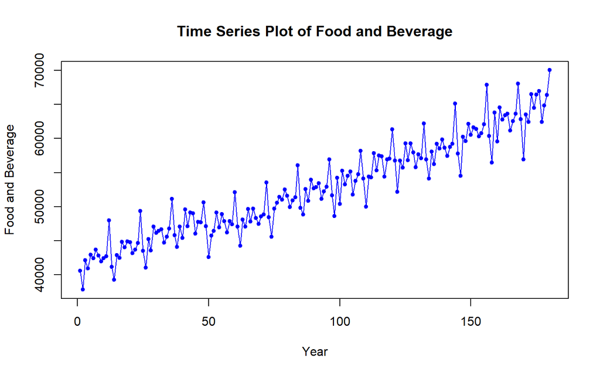

```r
ts.plot(musiman, type="l", xlab = "Year", ylab="Food and Beverage", col="blue")
title(main = "Time Series Plot of Food and Beverage", cex.sub = 0.8)
points(musiman, pch = 20, col = "blue")
```

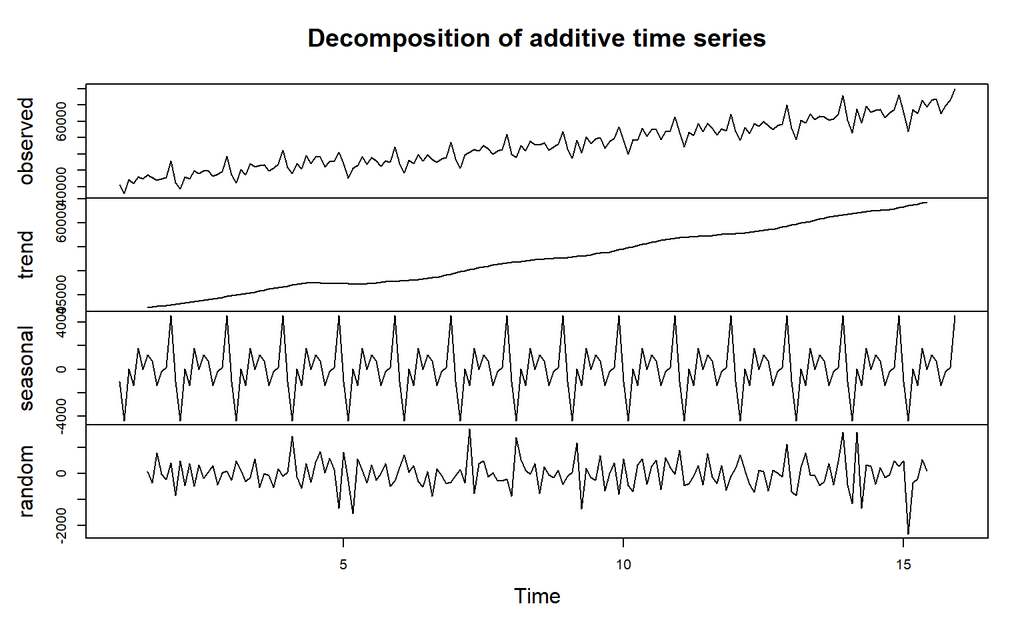

```r
musiman <- ts(musiman, frequency = 12) # Untuk data bulanan
dec.musiman <- decompose(musiman)
plot(dec.musiman)
```

Secara eksplorasi, terlihat adanya kecenderungan data memiliki tren naik dan perilaku berulang kecenderungan musiman dalam deret tersebut. Kecenderungan musiman dapat dilihat dengan lebih jelas dengan menampilkan deret waktu per tahun.

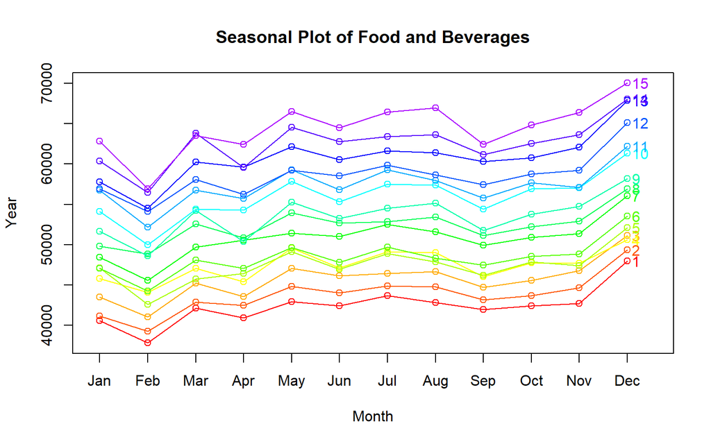

```r
seasonplot(musiman,12,main="Seasonal Plot of Food and Beverages", ylab="Year",
           year.labels = TRUE, col=rainbow(18))
```

Gambar menunjukkan bahwa food and beverages tinggi pada bulan Januari, Maret, Mei, Agustus, Desember, dan rendah pada bulan Februari, April, Juni, September. Perilaku tersebut terus berulang dari tahun ke tahun.

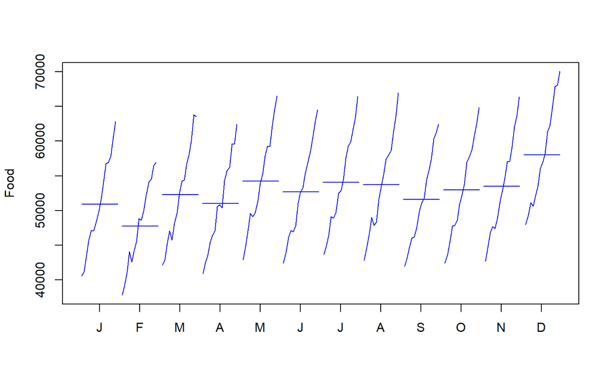

```r
monthplot(musiman,ylab="Food", col="blue")
```

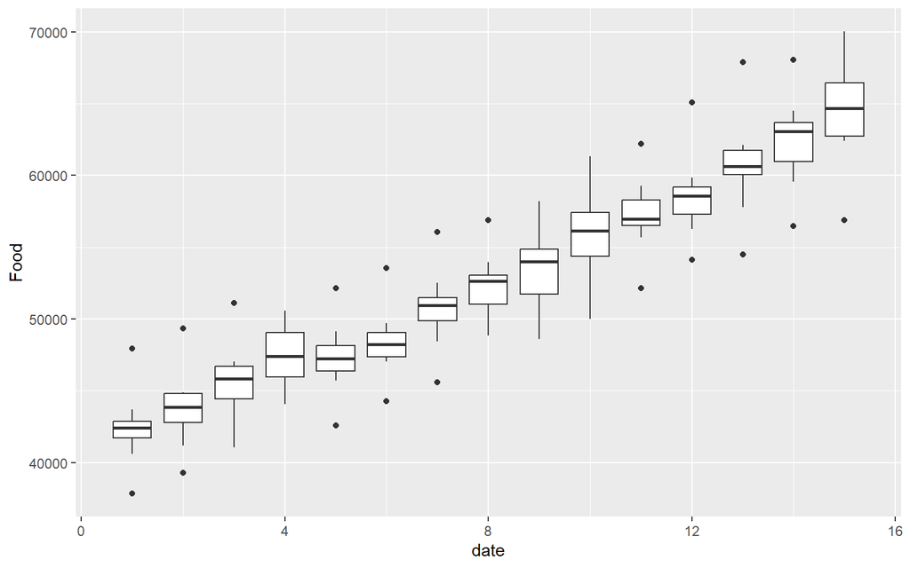

```r
frame<-data.frame(Food=as.matrix(musiman), date=lubridate::year(zoo::as.Date(musiman)))

library(ggplot2)
ggplot(frame,aes(y=Food,x=date,group=date))+
  geom_boxplot()
```

Berdasarkan hasil plot di atas dapat terlihat bahwa data memiliki pola yang hampir sama dari tahun ke tahun sehingga dapat disimpulkan bahwa periode musimannya adalah 12. Selain itu, apabila dilihat dari boxplot, terlihat bahwa data cenderung homogen dari tahun ke tahun meskupun terdapat beberapa pencilan. Untuk memastikan bahwa data homogen akan dilakukan uji homogenitas dengan `fligner.test`.

## Uji Homogenitas

Uji asumsi formal terhadap kehomogenan ragam yang digunakan yaitu *Fligner-Killen test*, dimana:

$H_0$ : Ragam homogen

$H_1$ : Ragam tidak homogen

```r
library(car)
fligner.test(Food ~ date, data=frame)
```

```
##
##  Fligner-Killeen test of homogeneity of variances
##
## data:  Food by date
## Fligner-Killeen:med chi-squared = 7.6117, df = 14, p-value = 0.9086
```

Berdasarkan hasil uji *Fligner-Killeen* dengan menggunakan taraf signifikansi $\alpha=5\%$ didapatkan *p-value* sebesar 0.9086. $p-value=0.9086>\alpha=0.05$ sehingga tak tolak $H_0$ atau dengan kata lain **ragam data sudah stasioner**.

# Pembagian Data

Pembagian data dilakukan dengan mengambil sekitar 86% data awal (156 observasi) sebagai data latih dan 14% sisanya (24 observasi) sebagai data uji.

```r
train.ts <- subset(musiman,start=1,end=156)
test.ts <- subset(musiman,start=157,end=180)
```

### Plot Data Latih

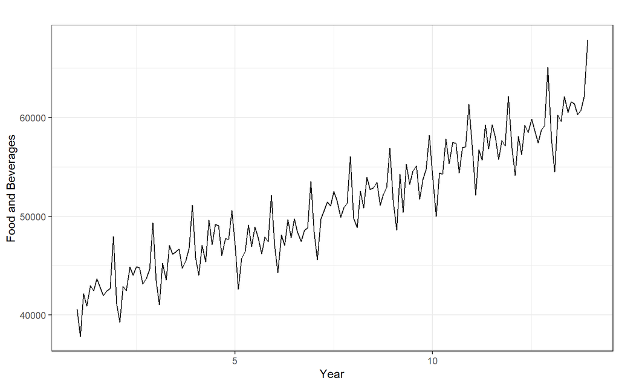

```r
autoplot(train.ts) + theme_bw() + xlab("Year") + ylab("Food and Beverages")
```

### Plot Data Uji

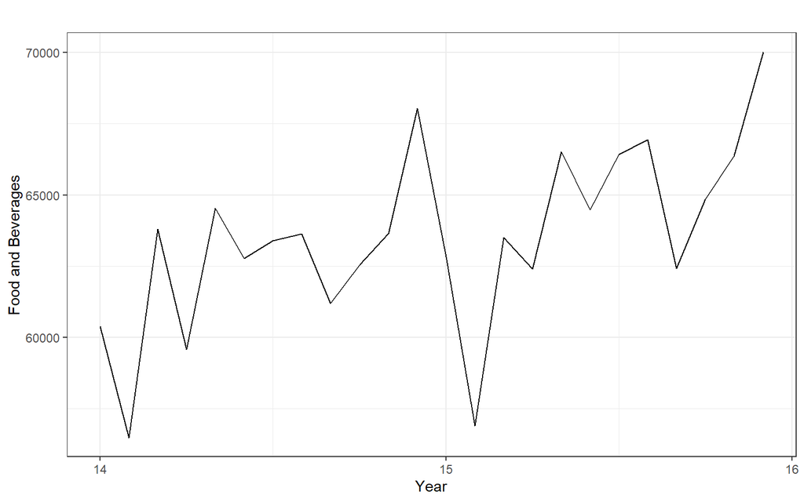

```r
autoplot(test.ts) + theme_bw() + xlab("Year") + ylab("Food and Beverages")
```

# Non-Seasonal ARIMA

## Kestasioneran Data

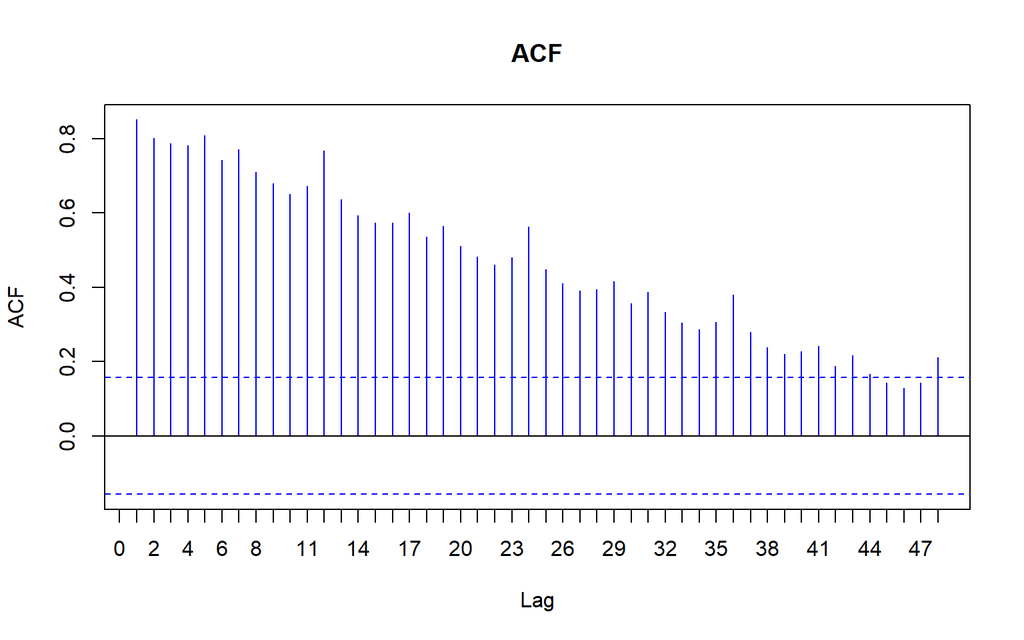

```r
acf0 <- acf(train.ts,main="ACF",lag.max=48,xaxt="n", col="blue")
axis(1, at=0:48/12, labels=0:48)
```

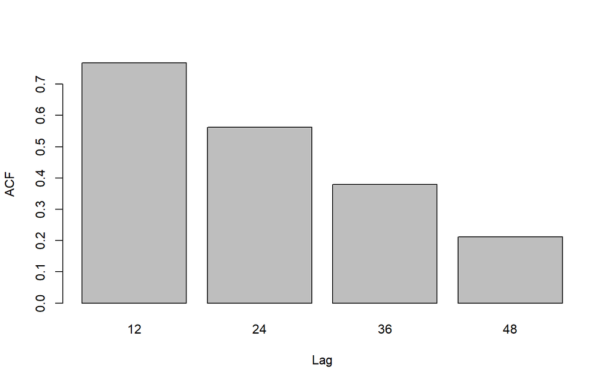

```r
acf0$lag <- acf0$lag * 12
acf0.1 <- as.data.frame(cbind(acf0$acf,acf0$lag))
acf0.2 <- acf0.1[which(acf0.1$V2%%12==0),]
barplot(height = acf0.2$V1,
names.arg=acf0.2$V2, ylab="ACF", xlab="Lag")
```

Berdasarkan plot deret sebelumnya diketahui bahwa perilaku deret berulang setiap tahun, atau dikatakan bahwa deret memiliki periode musiman bulanan, sehingga $s=12$. Perhatikan nilai fungsi autokorelasi pada lag-lag musiman (lag 12, 24, 36,...) dalam plot ACF contoh di atas. Tampak bahwa nilai autokorelasi pada lag-lag tersebut memiliki hubungan yang kuat. Bagaimanapun juga, plot ACF contoh meluruh secara perlahan dan membentuk pola gelombang kosinus teredam, yang menandakan ketidakstasioneran (plot deret juga menunjukkan adanya trend naik dalam deret).

```r
tseries::adf.test(train.ts)
```

```
##
##  Augmented Dickey-Fuller Test
##
## data:  train.ts
## Dickey-Fuller = -4.4893, Lag order = 5, p-value = 0.01
## alternative hypothesis: stationary
```

$H_0$ : Data tidak stasioner dalam rataan

$H_1$ : Data stasioner dalam rataan

Berdasarkan uji ADF tersebut, didapat *p-value* sebesar 0.01 yang lebih kecil dari taraf nyata 5% sehingga tolak $H_0$ dan menandakan bahwa data stasioner dalam rataan. Hal ini tidak sesuai dengan hasil eksplorasi menggunakan plot time series dan plot ACF, sehingga ketidakstasioneran model kedepannya harus tetap ditangani.

## Pembedaan

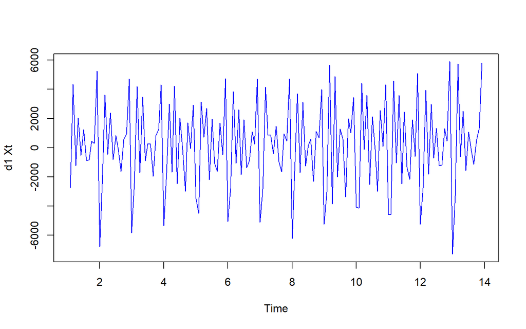

```r
d1 <- diff(train.ts)
ts.plot(d1, type="l", ylab="d1 Xt", col="blue")
```

*Differencing non-seasonal* $d=1$ jika dilihat berdasarkan plot di atas berhasil mengatasi ketidakstasioneran dalam rataan untuk komponen *non-seasonal*.

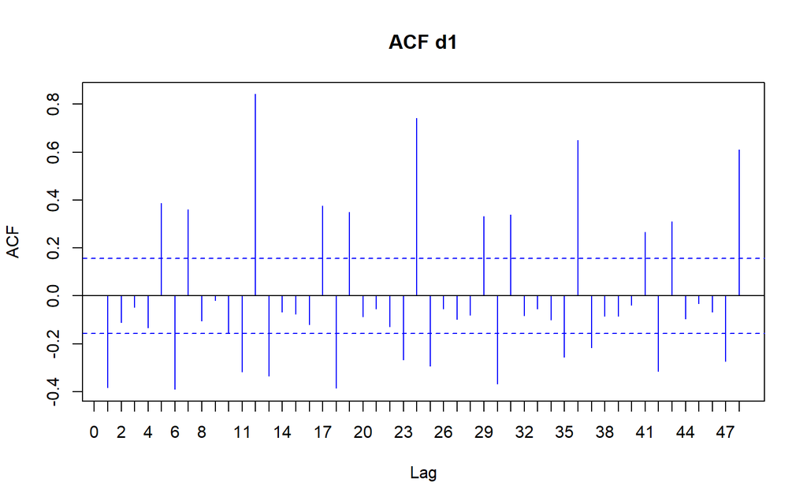

```r
acf1 <- acf(d1,lag.max=48,xaxt="n", main="ACF d1", col="blue")
axis(1, at=0:48/12, labels=0:48)
```

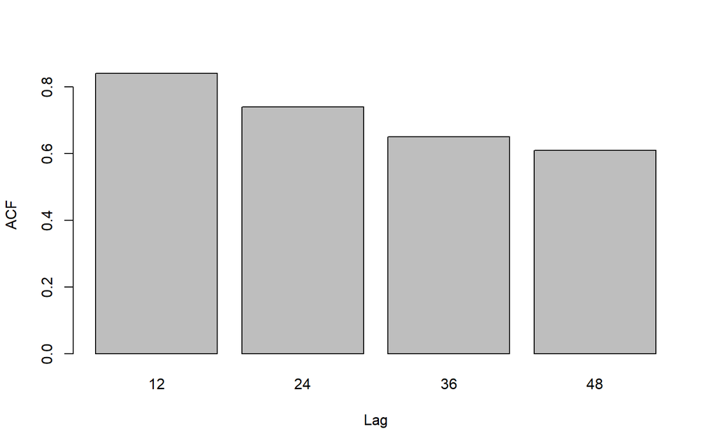

```r
acf2 <- acf1$lag <- acf1$lag * 12
acf1.1 <- as.data.frame(cbind(acf1$acf,acf1$lag))
acf1.2 <- acf1.1[which(acf1.1$V2%%12==0),]
barplot(height = acf1.2$V1, names.arg=acf1.2$V2, ylab="ACF", xlab="Lag")
```

Plot ACF data *non-seasonal differencing* $d=1$ mengkonfirmasi kestasioneran komponen *non-seasonal* (namun perhatikan lag 12,24, dst), pada *series* *seasonal* **belum stasioner**. Hal ini menunjukkan adanya kecenderungan musiman

# Seasonal ARIMA

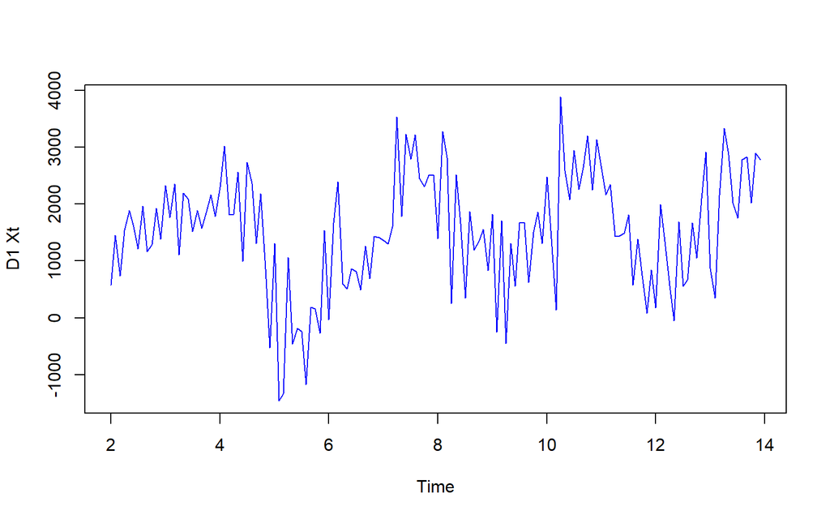

```r
D1 <- diff(train.ts,12)
ts.plot(D1, type="l", ylab="D1 Xt", col="blue")
```

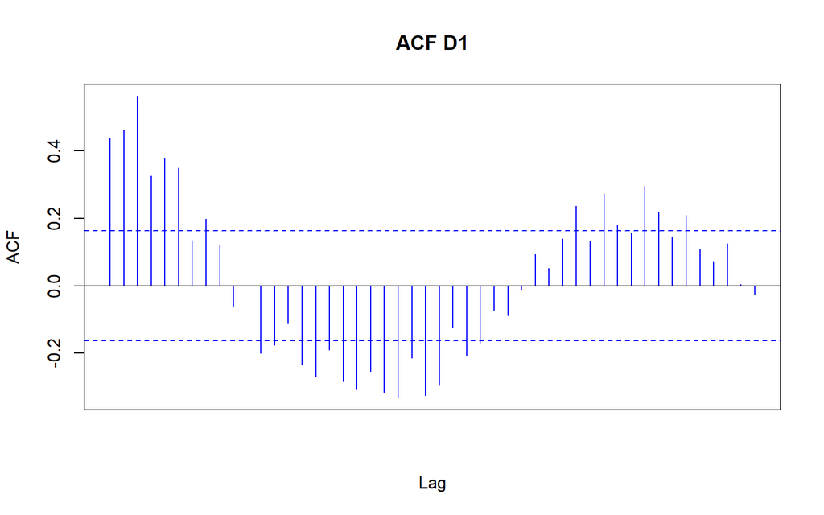

```r
acf2<-acf(D1,lag.max=48,xaxt="n", main="ACF D1", col="blue")
```

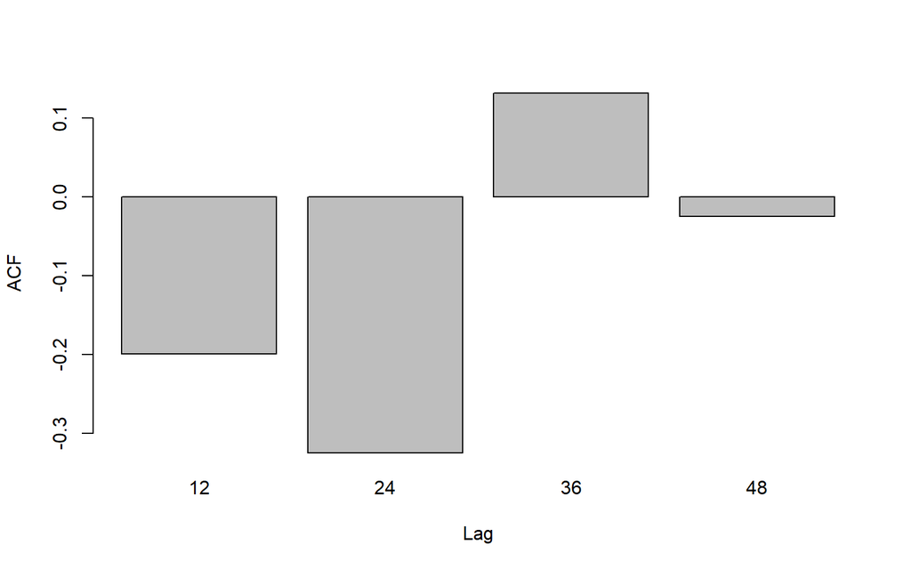

```r
acf2$lag <- acf2$lag * 12
acf2.1 <- as.data.frame(cbind(acf2$acf,acf2$lag))
acf2.2 <- acf2.1[which(acf2.1$V2%%12==0),]
barplot(height = acf2.2$V1, names.arg=acf2.2$V2, ylab="ACF", xlab="Lag")
```

Untuk menghilangkan kecenderungan musiman dilakukan pembedaan musiman terhadap deret hasil pembedaan pertama.

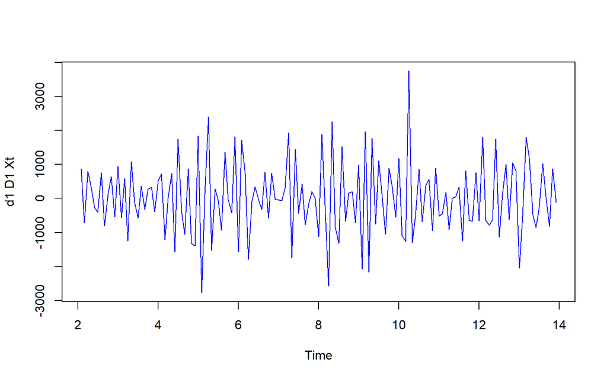

```r
d1D1 <- diff(D1)
ts.plot(d1D1, type="l", ylab="d1 D1 Xt", col="blue")
```

Setelah pembedaan pertama dan pembedaan musiman tampak bahwa deret sudah tidak memiliki kecenderungan apapun. Selanjutnya penentuan ordo *p*, *q* dan *P*, *Q* dapat dilakukan menggunakan plot ACF dan PACF contoh dari deret hasil pembedaan pertama dan pembedaan musiman tersebut.

## Identifikasi Model

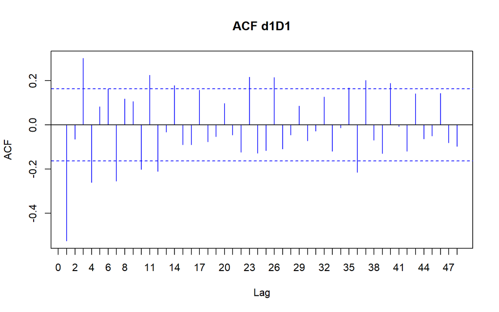

```r
acf3 <- acf(d1D1,lag.max=48,xaxt="n", main="ACF d1D1", col="blue")
axis(1, at=0:48/12, labels=0:48)
```

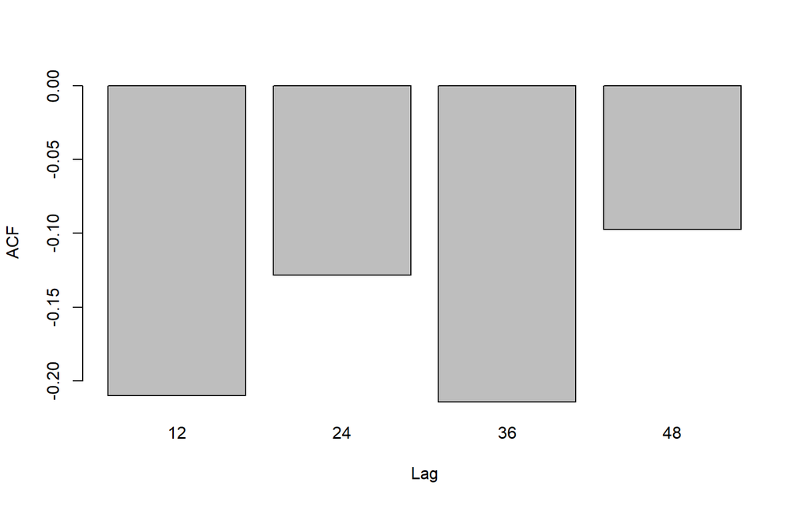

```r
acf3$lag <- acf3$lag * 12
acf3.1 <- as.data.frame(cbind(acf3$acf,acf3$lag))
acf3.2 <- acf3.1[which(acf3.1$V2%%12==0),]
barplot(height = acf3.2$V1, names.arg=acf3.2$V2, ylab="ACF",
xlab="Lag")
```

Berdasarkan plot ACF contoh lag 1 signifikan sehingga dipilih ordo *q*=1 , dan lag musiman tidak terlihat model AR yang terbentuk karena cenderung *tails-off* sehingga Q=0.

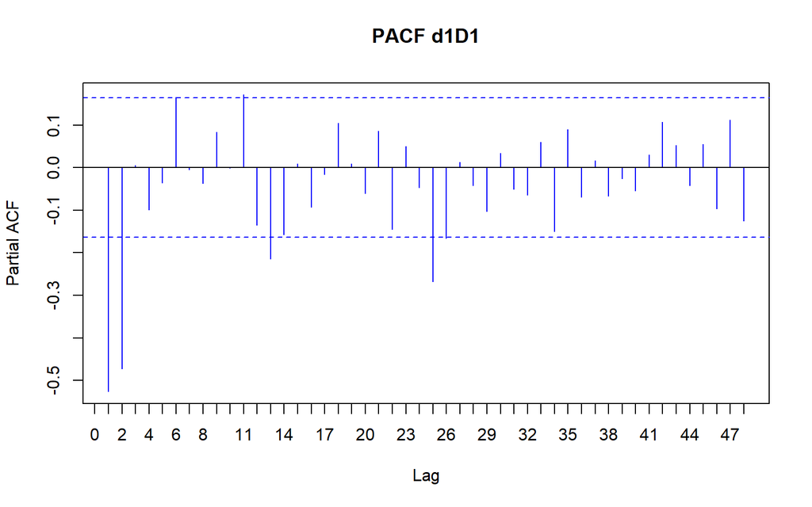

```r
pacf3 <- pacf(d1D1,lag.max=48,xaxt="n", main="PACF d1D1", col="blue")
axis(1, at=0:48/12, labels=0:48)
```

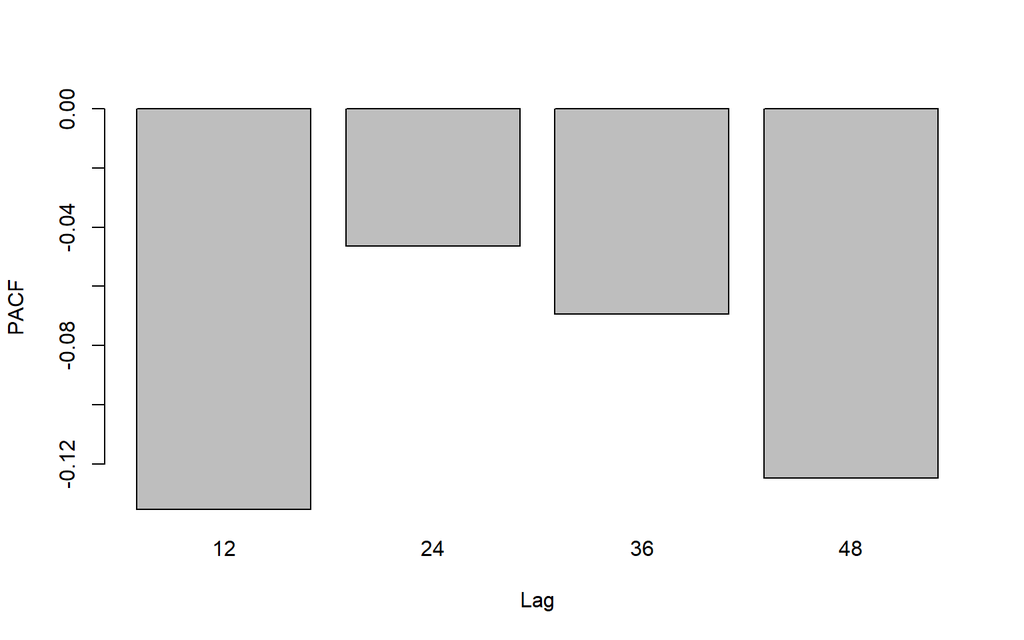

```r
pacf3$lag <- pacf3$lag * 12
pacf3.1 <- as.data.frame(cbind(pacf3$acf,pacf3$lag))
pacf3.2 <- pacf3.1[which(pacf3.1$V2%%12==0),]
barplot(height = pacf3.2$V1, names.arg=pacf3.2$V2, ylab="PACF", xlab="Lag")
```

Plot PACF contoh menunjukkan *cuts-off* pada lag-2 sehingga ordo *p*=2, sementara pada pola musimannya lag 12 cenderung cut off sehingga P=1

**EACF**

```r
TSA::eacf(d1D1)
```

```
## AR/MA
##   0 1 2 3 4 5 6 7 8 9 10 11 12 13
## 0 x o x x o o x o o x x  x  o  x
## 1 x o x x o o x o o o o  x  o  x
## 2 o x o o o o o o o o o  x  o  o
## 3 o x o x o o o o o o o  x  o  o
## 4 x x o x o o o o o o o  x  o  o
## 5 x x x x o o o o o o o  x  x  x
## 6 o x x o o o o o o o o  x  o  o
## 7 o o x o o o o o o o o  x  o  o
```

- $ARIMA(2,1,0)\times(1,1,0)_{12}$
- $ARIMA(0,1,2)\times(1,1,0)_{12}$
- $ARIMA(2,1,2)\times(1,1,0)_{12}$
- $ARIMA(2,1,3)\times(1,1,0)_{12}$
- $ARIMA(1,1,1)\times(1,1,0)_{12}$

## Pendugaan Parameter

```r
#ARIMA(2,1,0)x(1,1,0)12
tmodel1 <- Arima(train.ts,order=c(2,1,0),seasonal=c(1,1,0))
summary(tmodel1)
```

```
## Series: train.ts
## ARIMA(2,1,0)(1,1,0)[12]
##
## Coefficients:
##           ar1      ar2     sar1
##       -0.8264  -0.5230  -0.3572
## s.e.   0.0725   0.0725   0.0835
##
## sigma^2 = 587269:  log likelihood = -1152.43
## AIC=2312.86   AICc=2313.15   BIC=2324.71
##
## Training set error measures:
##                    ME     RMSE      MAE        MPE     MAPE      MASE
## Training set 33.26157 725.9727 542.4426 0.05183726 1.052167 0.3348942
##                    ACF1
## Training set 0.00655883
```

```r
lmtest::coeftest(tmodel1)
```

```
##
## z test of coefficients:
##
##       Estimate Std. Error  z value  Pr(>|z|)
## ar1  -0.826409   0.072510 -11.3972 < 2.2e-16 ***
## ar2  -0.522959   0.072470  -7.2162 5.347e-13 ***
## sar1 -0.357207   0.083484  -4.2788 1.879e-05 ***
## ---
## Signif. codes:  0 '***' 0.001 '**' 0.01 '*' 0.05 '.' 0.1 ' ' 1
```

```r
#ARIMA(0,1,2)x(1,1,0)12
tmodel2 <- Arima(train.ts,order=c(0,1,2),seasonal=c(1,1,0))
summary(tmodel2)
```

```
## Series: train.ts
## ARIMA(0,1,2)(1,1,0)[12]
##
## Coefficients:
##           ma1     ma2     sar1
##       -0.9111  0.3211  -0.3195
## s.e.   0.0856  0.0814   0.0834
##
## sigma^2 = 631254:  log likelihood = -1157.37
## AIC=2322.73   AICc=2323.02   BIC=2334.59
##
## Training set error measures:
##                    ME     RMSE      MAE        MPE     MAPE      MASE
## Training set 34.81516 752.6686 563.7383 0.05373695 1.093274 0.3480418
##                    ACF1
## Training set 0.02536796
```

```r
lmtest::coeftest(tmodel2)
```

```
##
## z test of coefficients:
##
##       Estimate Std. Error  z value  Pr(>|z|)
## ma1  -0.911053   0.085585 -10.6451 < 2.2e-16 ***
## ma2   0.321129   0.081385   3.9458 7.954e-05 ***
## sar1 -0.319537   0.083434  -3.8298 0.0001282 ***
## ---
## Signif. codes:  0 '***' 0.001 '**' 0.01 '*' 0.05 '.' 0.1 ' ' 1
```

```r
#ARIMA(2,1,2)x(1,1,0)12
tmodel3 <- Arima(train.ts,order=c(2,1,2),seasonal=c(1,1,0))
summary(tmodel3)
```

```
## Series: train.ts
## ARIMA(2,1,2)(1,1,0)[12]
##
## Coefficients:
##           ar1      ar2     ma1      ma2     sar1
##       -0.8931  -0.5249  0.0742  -0.0681  -0.3532
## s.e.   0.1407   0.0985  0.1586   0.1230   0.0839
##
## sigma^2 = 594114:  log likelihood = -1152.22
## AIC=2316.44   AICc=2317.06   BIC=2334.22
##
## Training set error measures:
##                    ME    RMSE      MAE        MPE     MAPE      MASE
## Training set 33.68291 724.957 540.2713 0.05260186 1.048458 0.3335537
##                      ACF1
## Training set -0.002099447
```

```r
lmtest::coeftest(tmodel3)
```

```
##
## z test of coefficients:
##
##       Estimate Std. Error z value  Pr(>|z|)
## ar1  -0.893115   0.140675 -6.3488 2.170e-10 ***
## ar2  -0.524880   0.098494 -5.3290 9.874e-08 ***
## ma1   0.074166   0.158594  0.4676    0.6400
## ma2  -0.068137   0.123033 -0.5538    0.5797
## sar1 -0.353151   0.083912 -4.2086 2.570e-05 ***
## ---
## Signif. codes:  0 '***' 0.001 '**' 0.01 '*' 0.05 '.' 0.1 ' ' 1
```

```r
#ARIMA(2,1,3)x(1,1,0)12
tmodel4 <- Arima(train.ts,order=c(2,1,3),seasonal=c(1,1,0))
summary(tmodel4)
```

```
## Series: train.ts
## ARIMA(2,1,3)(1,1,0)[12]
##
## Coefficients:
##           ar1      ar2     ma1     ma2      ma3     sar1
##       -1.1561  -0.9971  0.5305  0.3501  -0.5834  -0.4248
## s.e.   0.0070   0.0042  0.0632  0.0705   0.0608   0.0782
##
## sigma^2 = 493772:  log likelihood = -1142.26
## AIC=2298.52   AICc=2299.35   BIC=2319.26
##
## Training set error measures:
##                    ME    RMSE      MAE        MPE      MAPE      MASE
## Training set 32.25224 658.508 472.8635 0.05036343 0.9237744 0.2919373
##                     ACF1
## Training set -0.07357871
```

```r
lmtest::coeftest(tmodel4)
```

```
##
## z test of coefficients:
##
##        Estimate Std. Error   z value  Pr(>|z|)
## ar1  -1.1561244  0.0069541 -166.2507 < 2.2e-16 ***
## ar2  -0.9970522  0.0041564 -239.8863 < 2.2e-16 ***
## ma1   0.5305223  0.0631696    8.3984 < 2.2e-16 ***
## ma2   0.3500587  0.0704568    4.9684 6.750e-07 ***
## ma3  -0.5834457  0.0608073   -9.5950 < 2.2e-16 ***
## sar1 -0.4248081  0.0782237   -5.4307 5.614e-08 ***
## ---
## Signif. codes:  0 '***' 0.001 '**' 0.01 '*' 0.05 '.' 0.1 ' ' 1
```

```r
#ARIMA(1,1,1)x(1,1,0)12
tmodel5 <- Arima(train.ts,order=c(1,1,1),seasonal=c(1,1,0))
summary(tmodel5)
```

```
## Series: train.ts
## ARIMA(1,1,1)(1,1,0)[12]
##
## Coefficients:
##           ar1      ma1     sar1
##       -0.2706  -0.5485  -0.2894
## s.e.   0.1009   0.0753   0.0824
##
## sigma^2 = 657622:  log likelihood = -1160.1
## AIC=2328.19   AICc=2328.48   BIC=2340.04
##
## Training set error measures:
##                    ME     RMSE      MAE        MPE     MAPE      MASE
## Training set 36.77762 768.2275 582.5693 0.05720869 1.129692 0.3596677
##                     ACF1
## Training set -0.04773109
```

```r
lmtest::coeftest(tmodel5)
```

```
##
## z test of coefficients:
##
##       Estimate Std. Error z value  Pr(>|z|)
## ar1  -0.270640   0.100898 -2.6823  0.007311 **
## ma1  -0.548462   0.075294 -7.2843 3.234e-13 ***
## sar1 -0.289438   0.082390 -3.5130  0.000443 ***
## ---
## Signif. codes:  0 '***' 0.001 '**' 0.01 '*' 0.05 '.' 0.1 ' ' 1
```

```r
AICKandidatModel <- c(tmodel1$aic, tmodel2$aic, tmodel3$aic,
                      tmodel4$aic, tmodel5$aic)
AICcKandidatModel <- c(tmodel1$aicc, tmodel2$aicc, tmodel3$aicc,
                       tmodel4$aicc, tmodel5$aicc)
BICKandidatModel <- c(tmodel1$bic, tmodel2$bic, tmodel3$bic,
                      tmodel4$bic, tmodel5$bic)
KandidatModelARIMA <- c("ARIMA(2,1,0)(1,1,0)12", "ARIMA(0,1,2)(1,1,0)12",
                        "ARIMA(2,1,2)(1,1,0)12", "ARIMA(2,1,3)(1,1,0)12",
                        "ARIMA(1,1,1)(1,1,0)12")
compmodelARIMA <- cbind(KandidatModelARIMA, AICKandidatModel,
                        AICcKandidatModel, BICKandidatModel)
colnames(compmodelARIMA) <- c("Kandidat Model", "Nilai AIC",
                              "Nilai AICc", "Nilai BIC")
compmodelARIMA <- as.data.frame(compmodelARIMA)
compmodelARIMA
```

```
##          Kandidat Model        Nilai AIC       Nilai AICc        Nilai BIC
## 1 ARIMA(2,1,0)(1,1,0)12 2312.85756456884 2313.14741964131 2324.70894308988
## 2 ARIMA(0,1,2)(1,1,0)12 2322.73401238392 2323.02386745638 2334.58539090496
## 3 ARIMA(2,1,2)(1,1,0)12 2316.44184820616 2317.05949526498 2334.21891598771
## 4 ARIMA(2,1,3)(1,1,0)12 2298.51740642984 2299.34703605947 2319.25731884166
## 5 ARIMA(1,1,1)(1,1,0)12 2328.19258062385 2328.48243569631 2340.04395914489
```

Model **terbaik** berdasarkan nilai **AIC dan AICc terkecil** dari kandidat model **yaitu** $ARIMA(2,1,3)\times(1,1,0)_{12}$ dengan semua parameter yang signfikan

```r
model.auto.arima <- auto.arima(train.ts)
summary(model.auto.arima)
```

```
## Series: train.ts
## ARIMA(3,0,0)(0,1,1)[12] with drift
##
## Coefficients:
##          ar1     ar2     ar3     sma1     drift
##       0.0952  0.2793  0.5062  -0.8841  128.7331
## s.e.  0.0741  0.0730  0.0753   0.1301    7.9905
##
## sigma^2 = 421225:  log likelihood = -1143.3
## AIC=2298.61   AICc=2299.22   BIC=2316.42
##
## Training set error measures:
##                     ME     RMSE      MAE         MPE      MAPE      MASE
## Training set -11.06658 612.6358 448.8154 -0.04804293 0.8663892 0.2770905
##                    ACF1
## Training set 0.01270017
```

```r
lmtest::coeftest(model.auto.arima)
```

```
##
## z test of coefficients:
##
##         Estimate Std. Error z value  Pr(>|z|)
## ar1     0.095160   0.074111  1.2840 0.1991350
## ar2     0.279326   0.072984  3.8272 0.0001296 ***
## ar3     0.506238   0.075341  6.7193 1.826e-11 ***
## sma1   -0.884118   0.130125 -6.7944 1.088e-11 ***
## drift 128.733103   7.990462 16.1108 < 2.2e-16 ***
## ---
## Signif. codes:  0 '***' 0.001 '**' 0.01 '*' 0.05 '.' 0.1 ' ' 1
```